# Les applications indispensables des etudiants

Christophe Benavent - Université Paris Nanterre

22 mars 2020

[figure not shown]

from https://www.flickr.com/photos/cerillion/32343191178

# Préparation

Les éléments de code et les données sont disponibles dans le [repository](https://github.com/BenaventC/AppPortfolio). Vous pouvez aussi participer à l’enquête

## Le nombre d’applis

Trois questions ont été posées à une promotion de licence dans le cadre d’un cours de marketing. Ils y ont répondu avec application :

- Combien d’applications sont installées sur votre smartphone ?
- Combien en utilisez vous ?
- Lesquelles vous sont indispensables ? (énonciation)

En comptant les applis énoncées, on obtient une troisième mesure : le nombre d’applications jugées indispensables, et la liste des noms de ces applications.

Cette dernière question a du faire l’objet d’un retraitement manuel important. D’une part pour enlever les éléments de commentaires et ne garder que les “bag” d’application, ensuite pour uniformiser les dénomminations. On notera que si la plus part ont ennoncé simplement les applis, d’autres les ont classées par ordre d’importance, ou par champs d’utilisation.

Le résultat est clair. Le nombre d’applications jugées indispensables, et énoncées explicitement, a une médiane de 7. Le nombre médian d’application utiles déclaré est de 15. les applications installées sont de l’ordre de 51. Naturellement on donnera un plus grand crédit à la première statistique, mais on devra observer que le nombre d’applications installées a finalement peu de chance d’être dans les 7 ou 8 principales, dans un rapport de 1 à 7.

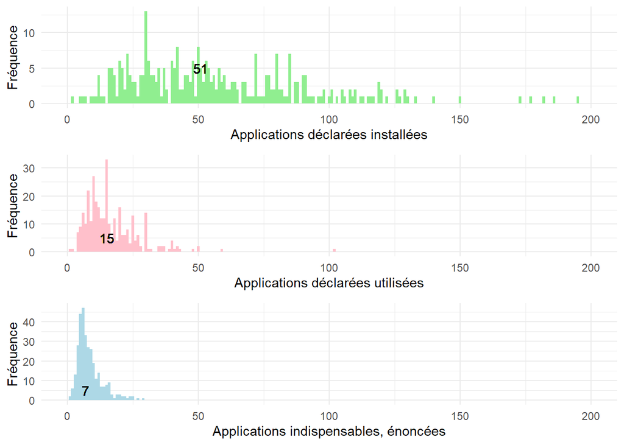

Quand on examine la corrélation entre le nombre d’applications indispensables et le nombre d’applications installées on observe que la corrélation n’est pas très forte et ne joue que dans la plage de 0 à 100 appli installées. Dans cette plage il y a une relation linéaire entre le nombre d’applis jugée indispensables et le nombre d’appli installées. c’est le signe d’une certaine appétence à réduire les problème par ce type d’outil. Audelà d’une centaine il n’y a plus de corrélation, c’est une sorte de limite d’apprentissage

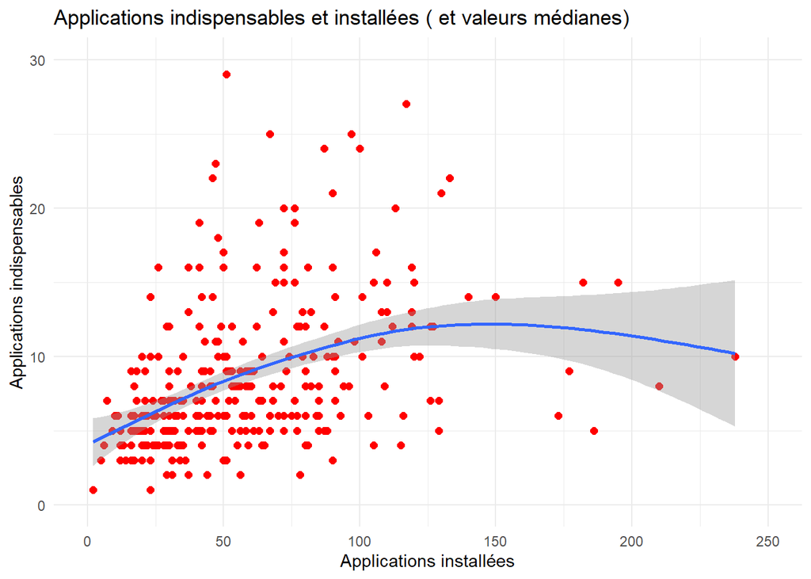

## La distribution des usages

```
##      feature frequency rank docfreq group
## 1  instagram       181    1     181   all
## 2   whatsapp       180    2     180   all
## 3   snapchat       143    3     143   all
## 4    youtube       118    4     117   all
## 5  messenger       108    5     108   all
## 6   facebook        90    6      90   all
## 7    spotify        89    7      89   all
## 8    twitter        87    8      87   all
## 9      gmail        76    9      76   all
## 10      ratp        65   10      65   all
```

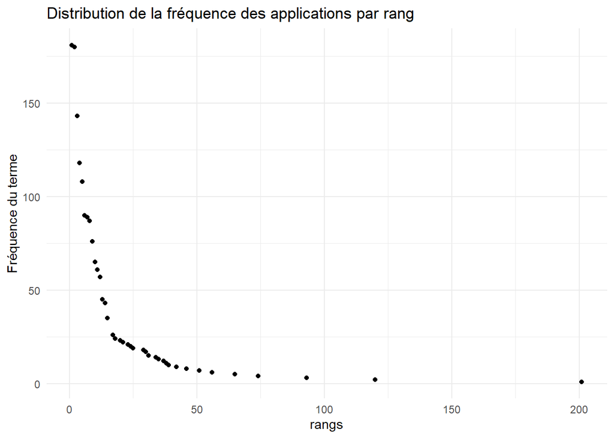

Avec un worcloud on represente plus concrètement les cinq applications qui dominent : whatsapp, instagram, snapchat, youtube, et messenger.La fonction sociale est dominante.

A une échelle inférieure on trouve des applications utilitaires et notamment celles du transports ( essentielles pour les étudiants)

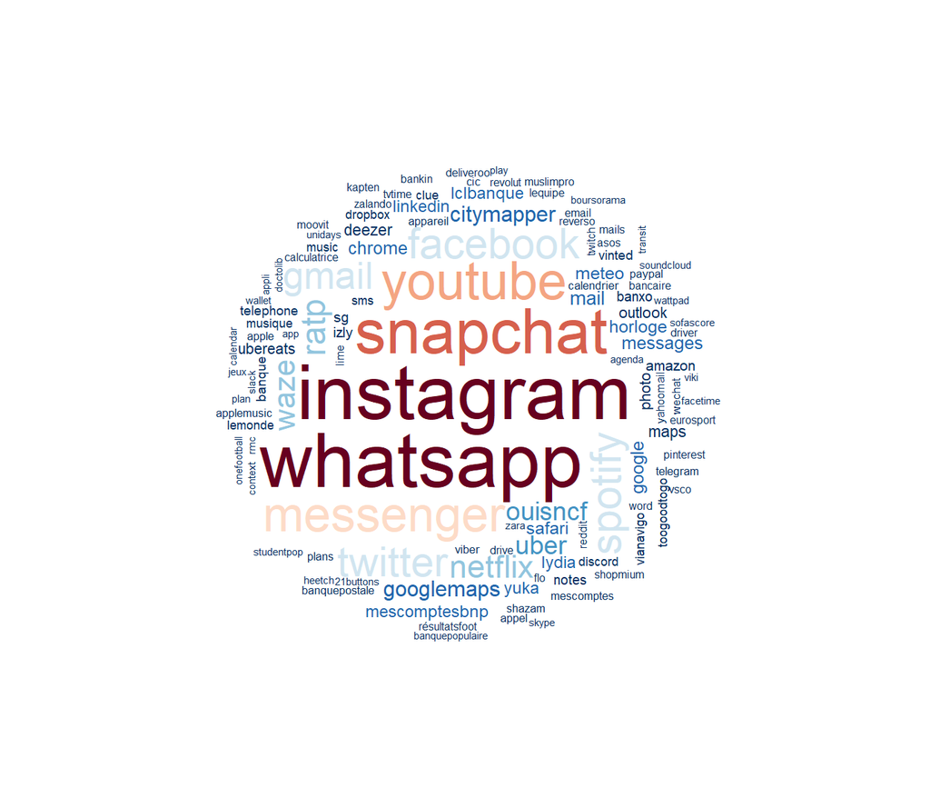

Pour une analyse plus fine on a catégorisé les applications et on représente celles qui ont été citées au moins 8 fois. Les catégories résultent d’un codage manuel des 120 applications dont la fréquence est > 3. Il est largement subjectif.

Il y a une hiérarchie des catégories : d’abord les réseaux sociaux, ensuite la mobilité, les utilitaires et ensuite les applis de consommation.

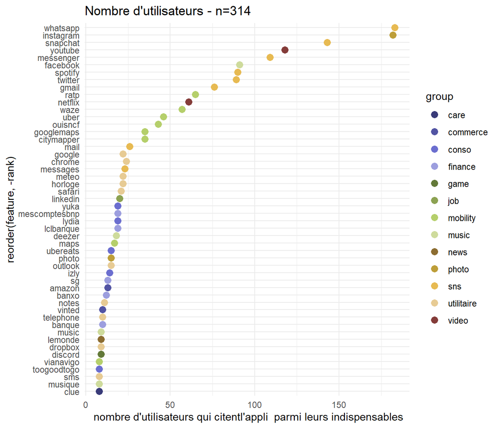

# Tentons un clustering

Avec une représentation sous forme de cladogramme par le package Ape

La mesure de distance est le le [coefficient de dice](https://fr.wikipedia.org/wiki/Indice_de_S%C3%B8rensen-Dice) mots. Deux mots seront d’autant plus proches qu’ils partagent les mêmes utilisateurs. Ce coefficient en effet rapporte le nombre de termes communs (les utilisateurs) à la somme des utilisateurs de chacune des applications.

Cette mesure ne mesure pas leur similarité fonctionnelle, mais des similarités d’usage, si on emploie une applis a -t-on de forte chance d’employer l’autre. Les groupes se determinent donc dans le co-usage, et signale moins des rapport de similarité fonctionnelle, que des rapport de complémentarité d’usage.

Pour bien comprendre le résultat, il faut se dire que les combinaisons de base se construisent sur un mix de quelques grandes fonctions :

- Communiquer avec les autres,
- S’informer sur l’actualité,
- Résoudre des problèmes de transports
- Résoudre des problèmes de consommation,
- Gérer ses finances et ses paiements
- Assurer des fonctionnalités de base
- S’occuper de son corps : le sport, le care,
- Ecouter de la musique, regarder des video, jouer, se cultiver

En examinant le cladogram on identifie 4 associations, on laisse au lecteur le soin de faire ses interprétations. Mais on gardera en tête qu’il y a une structure de base sans doute : un ou deux réseaux sociaux, des applications de mobilités, la banque et le paiement se dispersent. La presence d’applis typées par le genre (clue) , le centre d’interêt ( wattpad), le caractère commercial apportent des inflexions

1 - Optmimisers 2 - bon plans 3 - appleconso 4 - Urbains

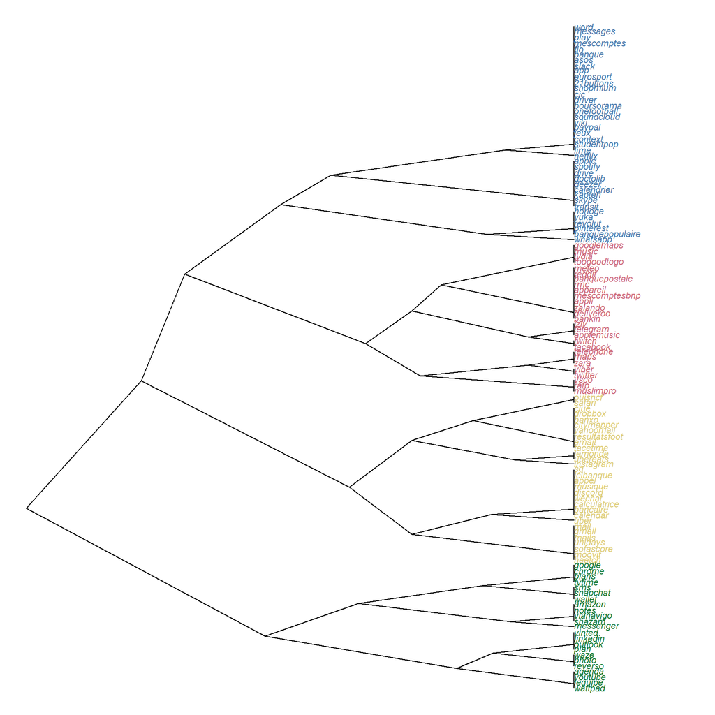

## Projetons dans un plan ces relations complexes

Comme il y a de nombreux objets, nous choisissons la méthode tsne qui permet un réglage fin des distances en fonction de la concentration des objets.

On utilise la métrique du cosinus. S’il est proche de 1, c’est que le terme utilisé est associé au terme test. Deux applis seront proches quand elles sont utilisées en même temps. La representation est obtenue avec Tsne en deux dimensions et avec une perplexité de 6.

LA carte est dupliquée pour representer a) les catégories d’application, b)la typologie des portfolios d’application.

On observe deux grands pôles.

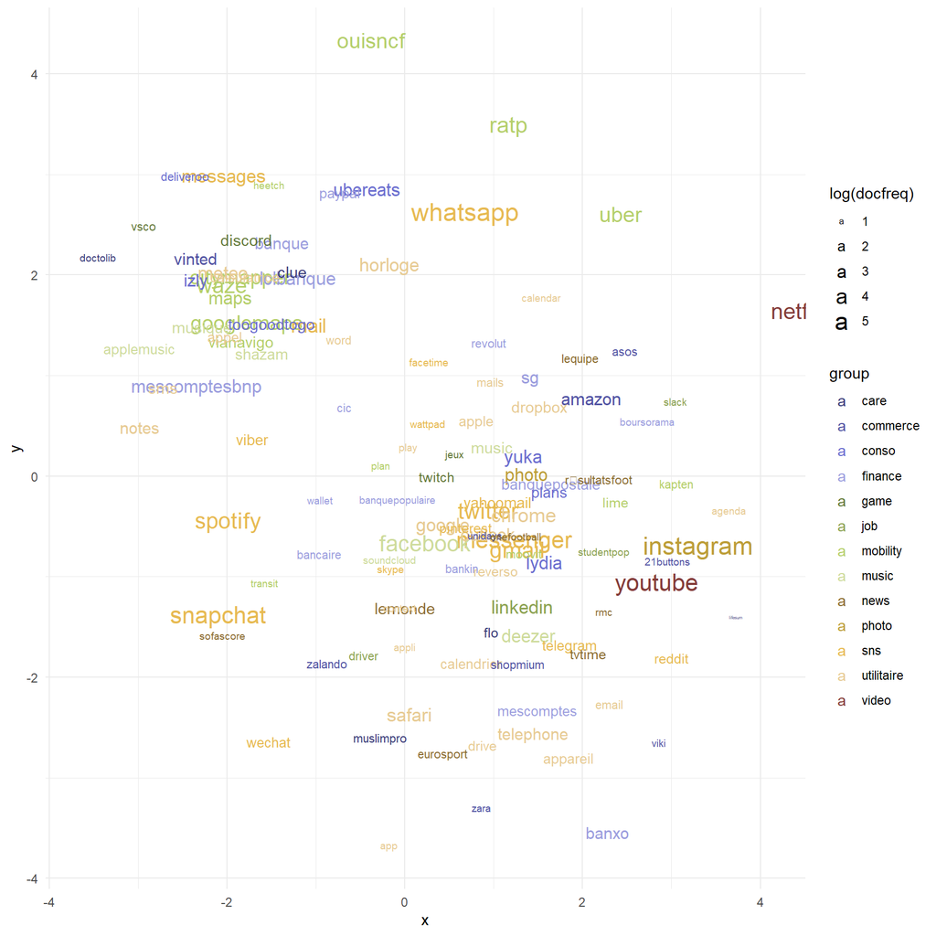

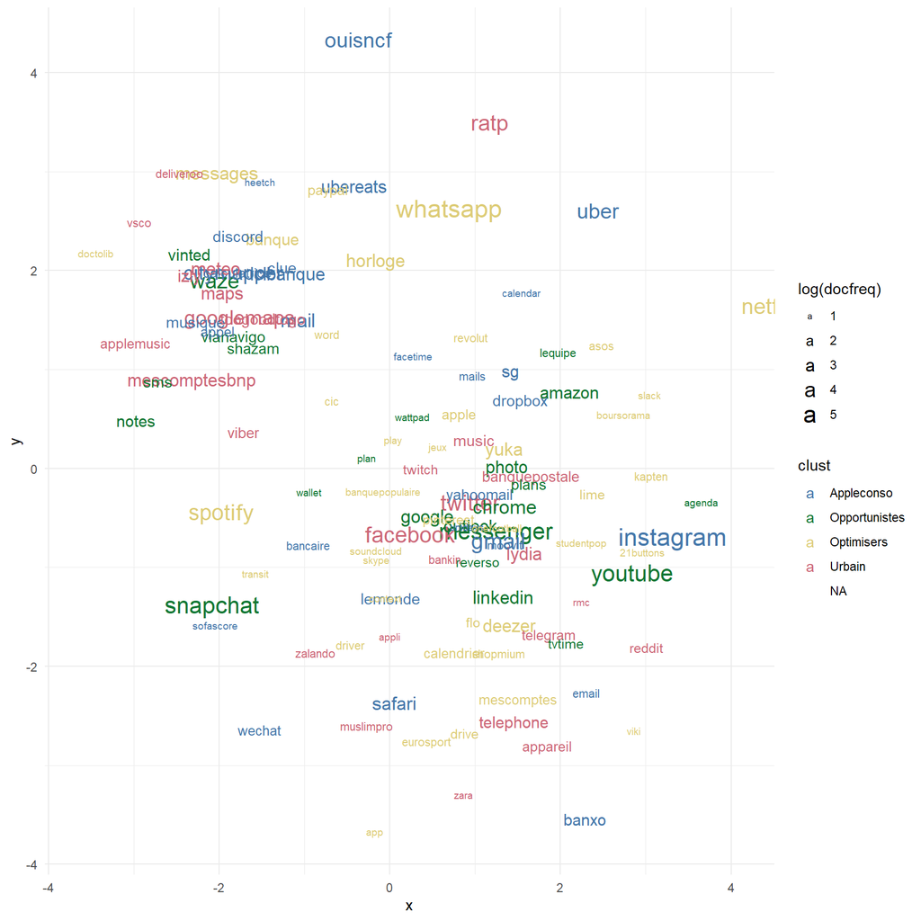